# (PSL) Clustering

## Multidimensional Scaling

To elucidate the concept of multidimensional scaling, let’s consider a dataset from a study that aimed to determine which pairs of letters people frequently confuse. The table below is from Wolford and Hollingsworth (1974). The set comprises eight letters: C, D, G, H, M, N, Q, and W. This results in an 8×8 matrix. Each cell in this matrix indicates the frequency with which people confuse the corresponding row and column letters.

```r
D = matrix(0, 8, 8)
letters = c("C", "D", "G", "H", "M", "N", "Q", "W")
colnames(D) = letters
rownames(D) = letters
D[2:8, 1] = c(5, 12, 2, 2, 2, 9, 1)
D[3:8, 2] = c(2, 4, 3, 4, 20, 5)
D[4:8, 3] = c(3, 2, 1, 9, 2)
D[5:8, 4] = c(19, 18, 1, 5)
D[6:8, 5] = c(16, 2, 18)
D[7:8, 6] = c(8, 13)
D[8, 7] = 4
D = (D+t(D))
D
```

```
##    C  D  G  H  M  N  Q  W
## C  0  5 12  2  2  2  9  1
## D  5  0  2  4  3  4 20  5
## G 12  2  0  3  2  1  9  2
## H  2  4  3  0 19 18  1  5
## M  2  3  2 19  0 16  2 18
## N  2  4  1 18 16  0  8 13
## Q  9 20  9  1  2  8  0  4
## W  1  5  2  5 18 13  4  0
```

The matrix $\mathbf{D}$ is symmetric and represents similarity, not distance. A higher value signifies that the two letters (row and column) are easily confused, indicating their similarity.

First, we change the similarity matrix $\mathbf{D}$ to a distance matrix $\mathbf{D}_0$ using the formula $21-\mathbf{D}$. This essentially inverts the sign, ensuring all entries remain positive (given the highest value in $\mathbf{D}$ is 20). The resultant matrix, $\mathbf{D}_0$, serves as our distance matrix. We also set the diagonal of $\mathbf{D}_0$ to zero since the distance between identical letters should always be zero.

```r
D0 = 21 - D
diag(D0) = 0
```

Applying multidimensional scaling to this matrix and by default embedding the data in a two-dimensional space, we get a visual representation. An alternative transformation for the similarity-to-distance matrix conversion, using $41-\mathbf{D}$, was also tried. The results were largely consistent, albeit with slight variations in scale.

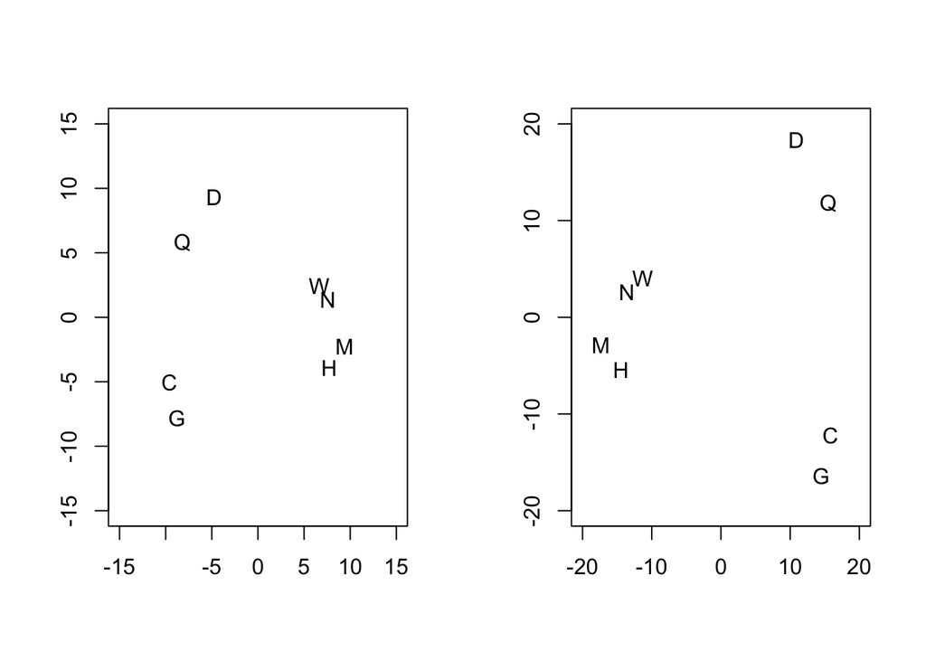

```r
tmp = cmdscale(D0)
par(mfrow=c(1,2))
plot(tmp[, 1], tmp[, 2], type="n", xlab="", ylab="",
     xlim = c(-15, 15), ylim=c(-15, 15))
text(tmp[, 1], tmp[, 2], label = letters)

D1 = 41 - D
diag(D1) = 0
tmp = cmdscale(D1)
plot(tmp[, 1], tmp[, 2], type="n", xlab="", ylab="",
     xlim = c(-20, 20), ylim=c(-20, 20))
text(tmp[, 1], tmp[, 2], label = letters)
```

From the visual representation, it becomes evident that the letters D and Q are similar, as are C and G. Additionally, a cluster of four other letters seems to share certain similarities.

## K-means

In our study, we apply clustering algorithms in R using the dataset “sportsranks”. This dataset contains over a hundred entries, each consisting of seven columns, with each column corresponding to a specific sport. Each entry, or row, represents an individual’s ranking preference for these seven sports, ranging from 1 to 7, without any ties.

```r
url = "https://raw.githubusercontent.com/liangfgithub/liangfgithub.github.io/master/Data/sportsranks.csv"
sportsranks = read.csv(url)
head(sportsranks)
```

```
##   Baseball Football Basketball Tennis Cycling Swimming Jogging
## 1        1        3          7      2       4        5       6
## 2        1        3          2      5       4        7       6
## 3        1        3          2      5       4        7       6
## 4        4        7          3      1       5        6       2
## 5        2        3          1      7       6        5       4
## 6        6        3          4      7       2        1       5
```

To analyze this data, we employed the K-means clustering method with K set to 2 and 3.

```r
km2=kmeans(sportsranks, centers=2, nstart=10);
km3=kmeans(sportsranks, centers=3, nstart=10);
```

To visualize the results, we utilized a multidimensional scaling (MDS) representation, plotted in a two-dimensional space. This MDS was calculated using the `cmdscale` command in R.

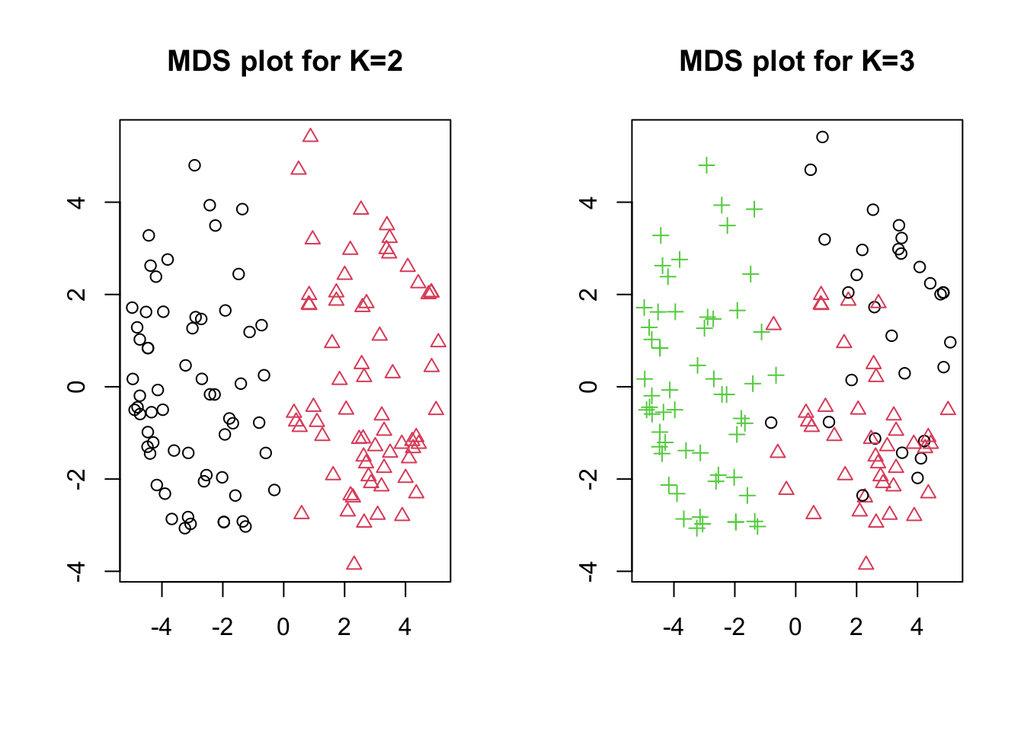

```r
D=dist(sportsranks)
Xmds=cmdscale(D);

par(mfrow=c(1,2));
plot(Xmds[,1], Xmds[,2], type="n", xlab="", ylab="")
points(Xmds[,1], Xmds[,2], pch=km2$cluster, col=km2$cluster);
title("MDS plot for K=2")
plot(Xmds[,1], Xmds[,2], type="n", xlab="", ylab="");
points(Xmds[,1], Xmds[,2], pch=km3$cluster, col=km3$cluster);
title("MDS plot for K=3")
```

Moreover, we manually computed the MDS by first applying double-centering, followed by singular value decomposition. We extracted the first two columns, essentially representing the two-dimensional space. A correlation check between our computed two-dimensional MDS and that returned by R revealed that they were virtually identical.

```r
D2 = as.matrix(D^2)
n = dim(D2)[1]
tmp = D2 - matrix(colMeans(D2), nrow=n, ncol=n, byrow=TRUE) -
  matrix(rowMeans(D2), nrow=n, ncol=n, byrow=FALSE)
tmp = -(tmp + mean(D2))/2
tmp.svd = svd(tmp)
F = tmp.svd$u[, 1:2]  %*% diag(sqrt(tmp.svd$d[1:2]))
cor(F, Xmds)
```

```
##               [,1]          [,2]
## [1,]  1.000000e+00 -6.602771e-17
## [2,] -1.697386e-16 -1.000000e+00
```

The plots indicate that setting K to 2 might be sufficient since using K = 3 began to display overlapping clusters. To verify our choice of K, we employed the gap statistic method.

## Gap Statistics

In R, there’s a specific command `clusGap` in the `cluster` package for computing this statistic. Our analysis using this method indicated that the optimal K is indeed 2.

```r
library(cluster)
set.seed(123)
gap_stat = clusGap(sportsranks, FUN = kmeans, nstart = 25,
                    K.max = 10, B = 50)
print(gap_stat, method = "firstmax")
```

```
## Clustering Gap statistic ["clusGap"] from call:
## clusGap(x = sportsranks, FUNcluster = kmeans, K.max = 10, B = 50,     nstart = 25)
## B=50 simulated reference sets, k = 1..10; spaceH0="scaledPCA"
##  --> Number of clusters (method 'firstmax'): 2
##           logW   E.logW       gap     SE.sim
##  [1,] 5.429866 5.647963 0.2180970 0.01818769
##  [2,] 5.229886 5.547803 0.3179171 0.01742745
##  [3,] 5.157134 5.474076 0.3169413 0.01756228
##  [4,] 5.099957 5.411790 0.3118326 0.01790591
##  [5,] 5.045671 5.358850 0.3131785 0.01753858
##  [6,] 4.997477 5.313087 0.3156102 0.01756705
##  [7,] 4.946452 5.271046 0.3245940 0.01776266
##  [8,] 4.909225 5.232372 0.3231469 0.01785827
##  [9,] 4.870644 5.197057 0.3264129 0.01841879
## [10,] 4.839642 5.163225 0.3235833 0.01786732
```

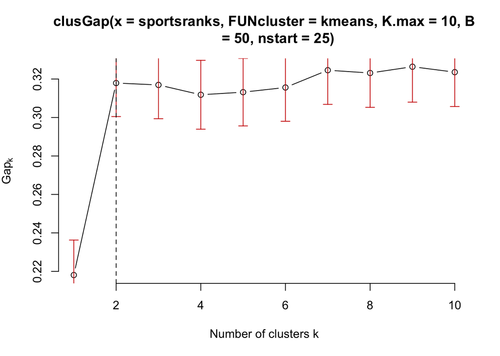

```r
plot(gap_stat, frame = FALSE, xlab = "Number of clusters k")
abline(v = 2, lty = 2)
```

We further broke down the process for computing the gap statistic.

- Step 1: Calculate Within-Cluster-SS. For various K values, we compute the Within-Cluster-SS for the observed data using K-means. This involved specifying K as the number of clusters and instructing R to run ten randomized initializations `nstart = 10`, selecting the one yielding the smallest sum.

```r
n=130;
SS=rep(0,10)
SS[1]=sum(diag(var(sportsranks)))*(n-1)
for(k in 2:10){
      kms=kmeans(sportsranks, centers=k, nstart=10)
      SS[k]=sum(kms$withinss)
      }
lss=log(SS)
```

- Step 2: Calculate SS_0(K) under Reference Distribution. For our data, the reference distribution was generated by creating samples where each entry was a random permutation of the numbers 1 through 7. This approach ensured that our reference data was devoid of any inherent clustering structure. We created 50 sets of this data and computed the Within-Cluster-SS for each set.

```r
n = dim(sportsranks)[1]
m = 7  # each review is a permutation of numbers from 1 to 7
B = 50 # number of iterations
lss0 = matrix(0,B,10)
for(b in 1:B){
  xstar=NULL
  for(i in 1:n){
    xstar = rbind(xstar, sample(m))
  }
  lss0[b,1] = log(sum(diag(var(xstar)))*(n-1))
  for(k in 2:10){
    kms = kmeans(xstar, centers=k, nstart=10)
    lss0[b,k] = log(sum(kms$withinss))
  }
}
```

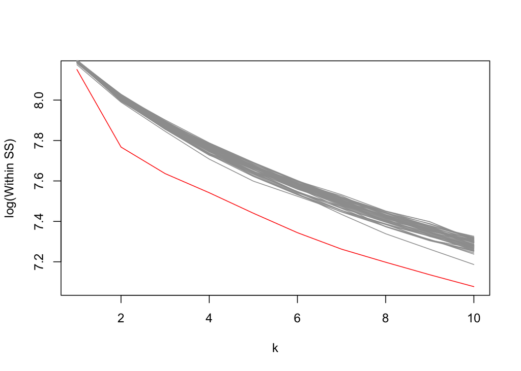

```r
plot(1:10, lss, type="l", col="red", xlab="k",
     ylab="log(Within SS)");
for(b in 1:B){
      points(1:10, lss0[b,], type="l", col=8)
}
```

Plot the Gap curve. Based on the 1se rule, the most considerable gap difference appeared at K=2. Thus, we concluded that K=2 is the optimal choice based on the gap statistic, confirming our earlier visual observations.

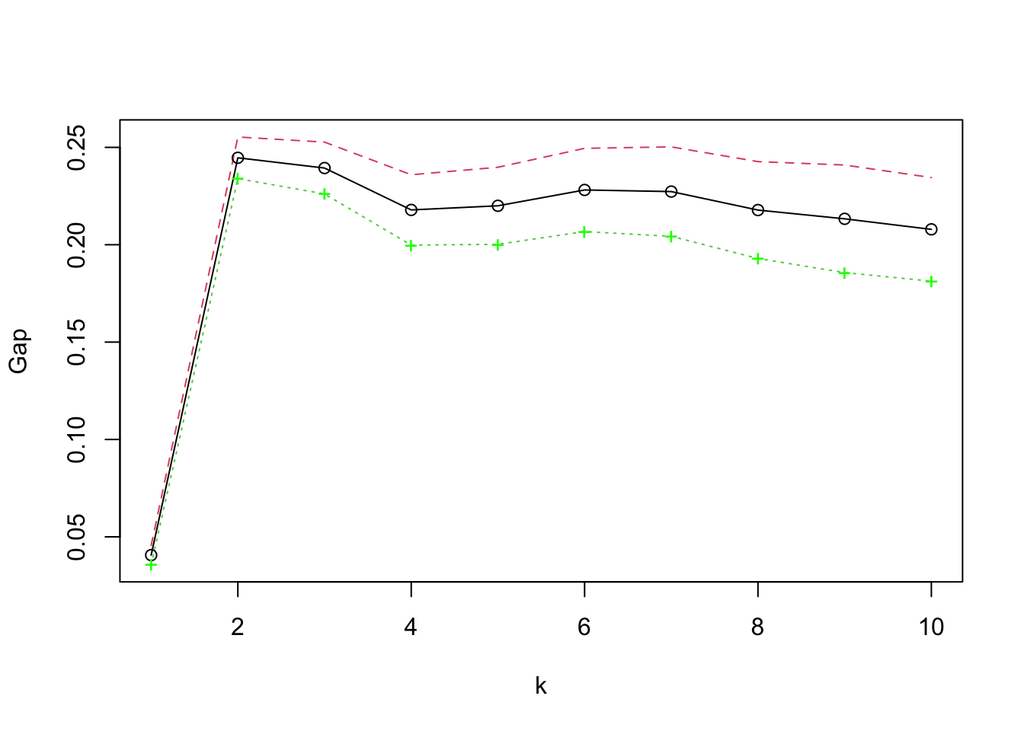

```r
lss0m = apply(lss0, 2, mean)
lss0sd = sqrt(apply(lss0, 2, var))*sqrt(1+1/B)
diff = lss0m-lss
matplot(1:10, cbind(diff, diff+lss0sd, diff-lss0sd), type="l",
        xlab="k", ylab="Gap")
points(1:10, diff)
points(1:10, diff-lss0sd, pch="+", col="green")
```

## Silhouette Plots

```r
sil2=silhouette(km2$cluster,D)
sil3=silhouette(km3$cluster,D)

par(mfrow=c(1,2))
plot(sil2)
plot(sil3)
```

Compute and plot average silhouette over a range of K values.

```r
k.max = 10
sil = rep(0, k.max)

# Compute the average silhouette width for
# k = 2 to k = 15
for(i in 2:k.max){
  tmp = kmeans(sportsranks, centers = i, nstart = 10)
  ss <- silhouette(tmp$cluster, dist(sportsranks))
  sil[i] <- mean(ss[, 3])
}

# Plot the  average silhouette width
plot(1:k.max, sil, type = "b", pch = 19,
     frame = FALSE, xlab = "Number of clusters k")
abline(v = which.max(sil), lty = 2)
```

## Prediction Strength

```r
library(fpc)
ps = prediction.strength(sportsranks, Gmax=10,
                          clustermethod=kmeansCBI)
```

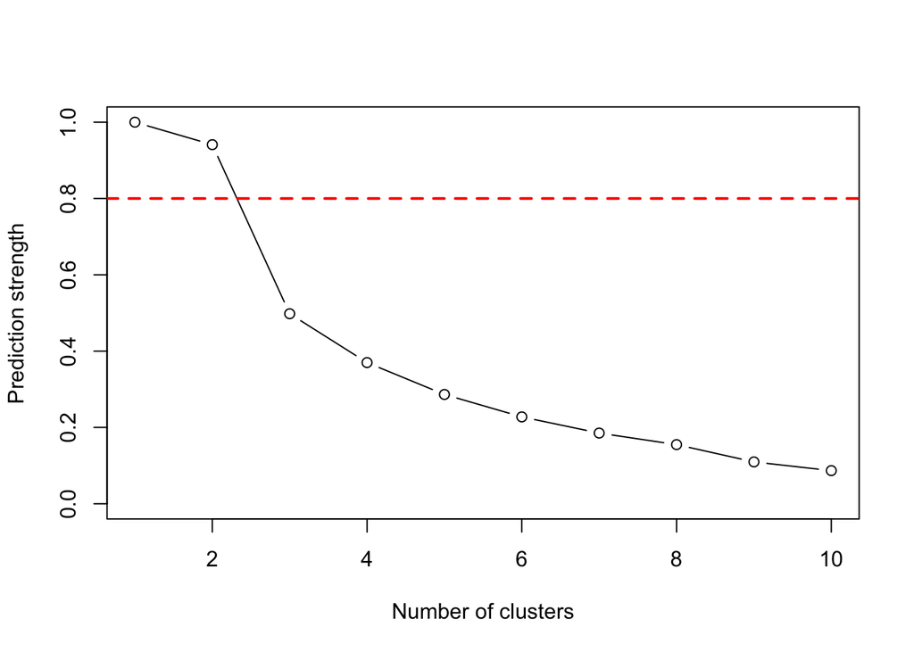

```r
plot(1:10, ps$mean.pred, type='b', ylim=c(0,1),
     xlab='Number of clusters', ylab='Prediction strength')
abline(h=ps$cutoff, col="red", lty=2, lwd=2)
```

## PAM

```r
pam2=pam(sportsranks, k=2);
plot(pam2)
```

```r
pam3=pam(sportsranks, k=3);
plot(pam3)
```

Visualize the clustering results

```r
par(mfrow=c(1,2));
plot(Xmds[,1], Xmds[,2], type="n");
points(Xmds[,1], Xmds[,2], pch=pam2$clustering, col=pam2$clustering);
title("MDS plot for K=2")
plot(Xmds[,1], Xmds[,2], type="n");
points(Xmds[,1], Xmds[,2], pch=pam3$clustering, col=pam3$clustering);
title("MDS plot for K=3")
```

Check how PAM results differ from the ones from K-means.

```r
table(pam2$clustering, km2$cluster)
table(pam3$clustering, km3$cluster)
```

## Hierarchical Clustering

```r
plot(hclust(dist(sportsranks)), xlab="Complete Linkage", sub="");
plot(hclust(dist(sportsranks), method="single"), xlab="Single Linkage", sub="");
plot(hclust(dist(sportsranks), method="average"), xlab="Average Linkage", sub="");
```

```r
clusters = hclust(dist(sportsranks), method="average")
clusterCut = cutree(clusters, 3)
table(clusterCut)
```

Check how `hclust` results differ from the ones from K-means.

```r
table(cutree(clusters, 2), km2$cluster)
table(cutree(clusters, 3), km3$cluster)
```

```r
clusters = hclust(dist(sportsranks))
table(cutree(clusters, 2), km2$cluster)
table(cutree(clusters, 3), km3$cluster)
```

## Vector Quantization

Let’s demonstrate an interesting application of k-means: image compression. Take, for instance, this image of my son alongside his cherished toy, Curious George.

[figure not shown]

```r
X = read.table("../image.txt");
X = as.matrix(X);
X = t(X[270:1,]);
image(X, col=gray((0:128)/128))
```

To compress this image, we segment it into small 6x6 patches. For each patch, we extract its grayscale values, representing them as a 36x1 vector. Consequently, our data matrix, which I refer to as `Z`, has dimensions 2700x36. This means the original image has been divided into nearly 3,000 individual patches.

```r
p = 36
Z = NULL
n = (270*360)/36
for(i in 1:(360/6))
    for(j in 1:(270/6)){
        k=6*(i-1); l=6*(j-1);
        Z=rbind(Z,as.vector(X[(k+1):(k+6), (l+1):(l+6)]))
        }
dim(Z)  # 2700x36
```

```
## [1] 2700   36
```

Every row in matrix `Z` represents a patch, depicted as a vector in this 36-dimensional space. We’ll then apply K-means to matrix Z, setting k=40. Consequently, we’ll identify 40 distinct cluster centers. Each of these centers is represented by a 36x1 vector, which can also be visualized as a 6x6 patch.

With these centers in hand, we’ll reconstruct the image, replacing the original 6x6 patches with their nearest cluster centers. The end result is an image reconstructed using only **40** unique patches. Naturally, this compressed image isn’t as detailed as the original, which utilized **2,700** distinct patches, but it significantly reduces the file size. Despite this compression, the main features remain discernible: we can still identify both my son’s face and Curious George. And impressively, the entire compression process hinges on the simple K-means algorithm.

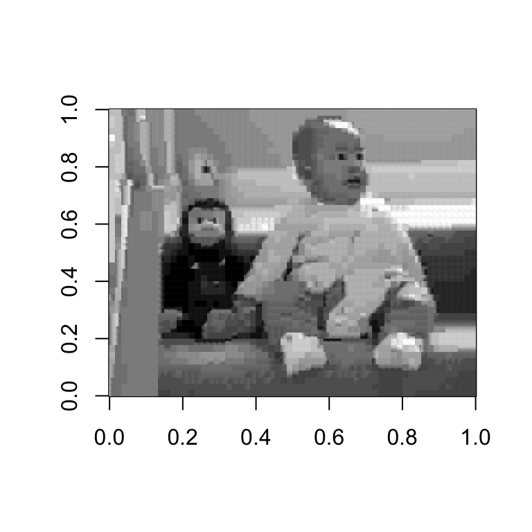

```r
# run k-means with K=40 centers
mykm = kmeans(Z, centers=40, nstart=10)

# Use the 40 patches to replace 2700 patches in the original image
# The new image uses only 40 disctive patches
newX = matrix(0,360,270)
m = 0
for(i in 1:(360/6))
    for(j in 1:(270/6)){
        k = 6*(i-1)
        l = 6*(j-1)
        m = m+1;
        tmp = mykm$center[mykm$cluster[m],]
        newX[(k+1):(k+6), (l+1):(l+6)] = matrix(tmp,6,6);
    }
image(newX, col=gray((0:128)/128))
```